# Visualizing Armed Conflict

Alan Peral and Kadija Yilla

12/12/2017

# Introduction

Since the end of the cold war in 1991, 2016 was the fifth most violent year in the world (Dupuy et al. 2015). Currently in 2017, there are more than 40 active conflicts in the world right now. Armed conflicts severely affect the lives of individuals in those countries currently. Most of the data online, outlines the armed conflict and casualties of the war. Others also include an [interactive feature](https://www.irinnews.org/maps-and-graphics/2017/04/04/updated-mapped-world-war) of the global conflict to observe the scale of the conflict, with respect to other nations. One [special interactive map](https://www.cfr.org/interactives/global-conflict-tracker#!/) illustrates how various armed conflict affect US interests. Despite all the information surrounding global conflicts, none accurately depict how the conflict has affected the lives of the individuals alive and living amidst the war.

War impacts people profoundly, and yet countries like the US insist on engaging in numerous armed conflicts regardless of the outcome. Westernized people, on account of the privilege awarded by not being engaged in the conflict on a daily basis, rarely underatand the impact of war on the population. How has the war impacted education? Are more males leaving school as a result of the conflict? What about women? How has the war impacted the need to have equal education for women? How has the conflict caused the governmental expenditures to changes? Is there more funding for the various industries or are a mojortiy of the funding being exploited to arm the conflict? In addition, do the citizens have access to water, electricity, and housing and basic human rights?

# Data

The first data set used is from [Kaggle](https://www.kaggle.com/sdorius/globses/data) titled “Country Socioeconomic Status Scores.” This data set includes the overall score of socioeconomic sattus by country for every decade since 1880. Socioeconomic Status (SES) Scores measure the accesibility of an individual, household, or community to collective resources. This measure incoprorates, income, wealth, health, and occupation (Psaki et al. 2014). For each country, this indivudialzied measure is aggregated as a whole to provide the measure for the country.

```
## # A tibble: 5 x 6
##    wbid     country  year   SES gdppc popshare
##   <chr>       <chr> <int> <dbl> <dbl>    <dbl>
## 1   AFG Afghanistan  2010  5.68  1663  0.00415
## 2   AFG Afghanistan  2000  2.06   565  0.00331
## 3   AFG Afghanistan  1990  1.27   604  0.00235
## 4   AFG Afghanistan  1980  3.47   690  0.00306
## 5   AFG Afghanistan  1970  3.47   709  0.00310
```

- health expenditure, total (% of GDP)
- fertility rate, tota (births per total)
- life expectancy at birth, female (years)
- life expectancy at birth, total (years)
- mortality rate, under-5 (per 1000 live births)
- children in employment, total (% of children 7-14)
- labor force, female (% of total labor force)
- labor force participation rate, female (% of female population ages 15+)(modeled ILO estimate) indicator
- GINI index (World Bank estimate) indicator
- Refugee population by country or territory of origin ()
- Refugee population by country or territory of asylum ()
- Improved sanitation facilities (% of population with access) indicator
- Improved water source (% of population with access) indicator
- Access to electricity (% of population) indicator
- Population living in slums (% of urban population) indicator

```
##      country year fetility_rate life_expectancy_female
## 1 Arab World 1960          6.95                   47.9
## 2 Arab World 1961          6.97                   48.5
## 3 Arab World 1962          6.99                   49.1
## 4 Arab World 1963          7.01                   49.7
## 5 Arab World 1964          7.02                   50.3
```

The third and final set is data about armed conflicts from the Uppsala Conflict Data Program (UCDP) at the department of Peace and Conflict Research, Uppsala University and the Centre for the Study of Civil War at the Peace Research Institute Oslo (PRIO). The UCDP/PRIO Armed Conflict Dataset represents both internal and external conflict from 1946 to the present. It documents the two sides in the conflict, as well as the location of the conflict, and indicators of intensity and number of fatalities. Armed conflict is defined as (2002):

> “A contested incompatibility that concerns government and/or territory where the use of armed force between two parties, of which at least one is the government of a state, results in at least 25 battle-related deaths in a calendar year” – Gleditsch et al. (2002)

```
## # A tibble: 5 x 4
##               location                 sidea
##                  <chr>                 <chr>
## 1              Bolivia Government of Bolivia
## 2              Bolivia Government of Bolivia
## 3              Bolivia Government of Bolivia
## 4 Cambodia (Kampuchea)  Government of France
## 5 Cambodia (Kampuchea)  Government of France
## # ... with 2 more variables: `side b` <chr>, year <int>
```

### Wrangling

Using the three seperate sets, we were able to construct a comprehsnive data set of all necessary information using data wrangling techniques.First we merged the SES scores set, **SES.data**, with the WBD data, **WBD.data2** by merging based on the country first and then the year. Before the merge was successful, the country names had to be reconciled because of subtle differences in naming techniques. For example, “Korea, Dem. People’s Rep.” in the WBD set had to be renamed to “North Korea” as that was the name in te SES set. We choose to rename the countries based on names we thought the general public would be more familiar with.

```
##       country unid wbid  SES
## 1 Afghanistan    4  AFG 38.0
## 2 Afghanistan    4  AFG 29.6
## 3 Afghanistan    4  AFG 28.1
## 4 Afghanistan    4  AFG 27.0
## 5 Afghanistan    4  AFG 27.0
```

Next we take the established **WBD.SES** set and merge with the **conflict.data** set based on the “country”/“location.” In order to create a tidy data set upon merge, we had to clean-up the conflict set for the “location” variable. For some conflicts in which the conflict occured in different locations globally, we had to seperate the countries in the “location” field and recreate the data for the seperately valued contries. To achieve this we had to create a user-fucnction that replicated the speicified joined countries and duplicated the values in one step. For example, the India vs. Pakistan War of 1965 occured in both India and Pakistan but was represented as “India, Pakistan”.

```
## # A tibble: 5 x 4
##          location               sidea               `side b`  year
##             <chr>               <chr>                  <chr> <int>
## 1 India, Pakistan Government of India Government of Pakistan  1948
## 2 India, Pakistan Government of India Government of Pakistan  1964
## 3 India, Pakistan Government of India Government of Pakistan  1965
## 4 India, Pakistan Government of India Government of Pakistan  1971
## 5 India, Pakistan Government of India Government of Pakistan  1984
```

This was instead changed to:

```
## # A tibble: 5 x 4
##   location               sidea               `side b`  year
##      <chr>               <chr>                  <chr> <int>
## 1    India Government of India Government of Pakistan  1948
## 2 Pakistan Government of India Government of Pakistan  1948
## 3    India Government of India Government of Pakistan  1964
## 4 Pakistan Government of India Government of Pakistan  1964
## 5    India Government of India Government of Pakistan  1965
```

In addition, we had to conduct a few name changes to reconcile the differences in set to have a bigger join. The final set which we will be working with is displayed below. The set excludes the regions created in the WBD set for summary purposed such as “Small States” and “Low Middle Income” countries. This set is comprehensive as it includes the SES work for the decade, other country-specific indicators, and information about the conflict for a specific year.

```
##         location year                     sidea
## 1    Afghanistan 1990 Government of Afghanistan
## 2        Albania 1990                      <NA>
## 3        Algeria 1990                      <NA>
## 4 American Samoa 1990                      <NA>
## 5        Andorra 1990                      <NA>
##   labor_force_Particpation_rate   SES
## 1                         16.44  1.27
## 2                         53.15 72.88
## 3                          9.93 56.71
## 4                            NA    NA
## 5                            NA    NA
```

# Results

The entire shiny application can be accessed by visiting: https://yillak.shinyapps.io/armed_conflicts2/

There a wide range of observations seen through the various apps on the page. When viewing the map graph we see that the countries with a majority of the conflicts are in the global south. The two countries with the most conflicts are India and Mynamar. Doing further research with our data, we observe that the United Kingdom is the first western country in the list and that occurs in the 26th place, having 29 conflicts occuring in that location. But in total, the UK has been involved with 203 armed conflicts globally. Similarly the United States has been in 173 conflicts but only 21 of those hace occured within the country. On the other hand, India has been involved with 218 conflicts but 194 has occured in India. This aids to our hypothesis that most conflicts although involving western countries are not fought in those countries therefore most of the effects of the war will not be seen in the western country, but in the country on the other side of the war.

```
## # A tibble: 119 x 2
##       location count
##          <chr> <int>
##  1     Myanmar   271
##  2       India   194
##  3    Ethiopia   127
##  4 Philippines   100
##  5      Israel    84
##  6        Iraq    73
##  7     Vietnam    54
##  8    Colombia    53
##  9    Pakistan    52
## 10   Indonesia    51
## # ... with 109 more rows
```

```
## [1] 203
```

```
## [1] 173
```

```
## [1] 218
```

| Country | Number of Conflicts | Number of Conflicts on Location |
| --- | --- | --- |
| United States | 173 | 21 |
| United Kingdom | 203 | 29 |
| India | 218 | 194 |

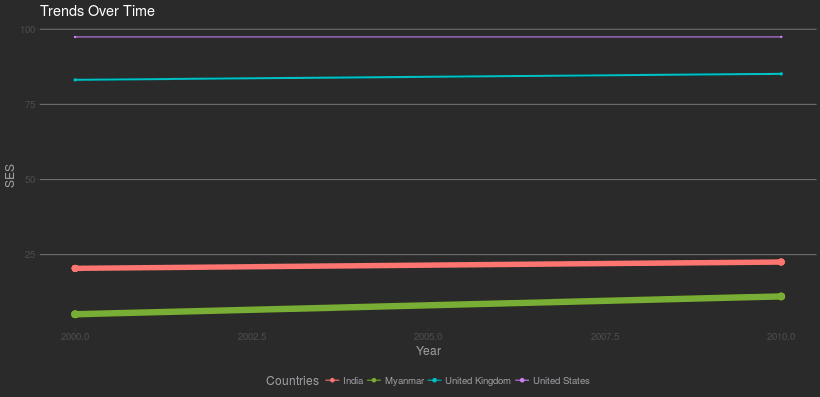

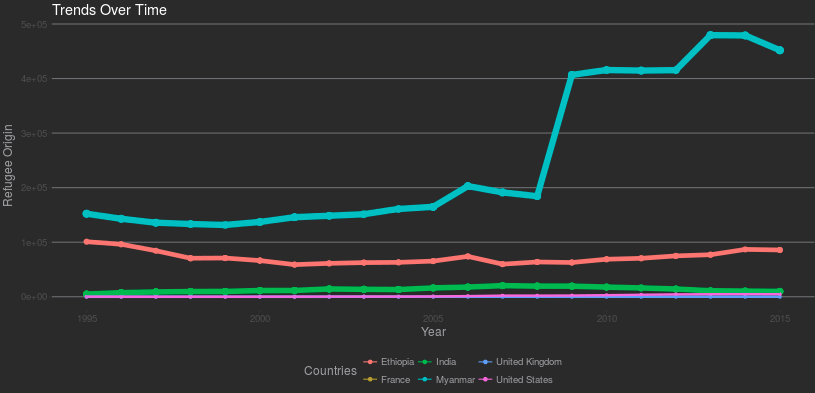

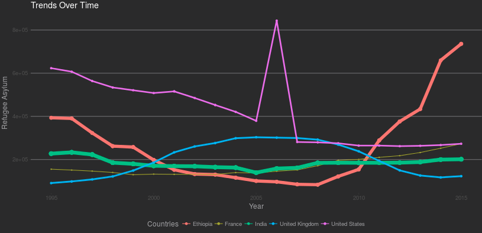

# References

Dupuy, Kendra, Scott Gates, Håvard Mokleiv Nygård, Ida Rudolfsen, Siri Aas Rustad, Håvard Strand, and Henrik Urdal. 2015. “Trends in Armed Conflict, 1946–2016.” Peach Research Institute OSLO. https://www.prio.org/utility/DownloadFile.ashx?id=1373&type=publicationfile.

Gleditsch, Nils Petter, Peter Wallensteen, Mikael Eriksson, Margareta Sollenberg, and Håvard Strand. 2002. “Armed Conflict 1946-2001: A New Dataset.” *Journal of Peace Research* 39 (5).

Psaki, Stephanie R, and Jessica C Seidman, Mark Miller, Michael Gottlieb, Zulfiqar A Bhutta, Tahmeed Ahmed, AM Shamsir Ahmed, et al. 2014. “Measuring Socioeconomic Status in Multicountry Studies: Results from the Eight-Country MAL-ED Study.” *Population Health Metrics* 12 (1). Springer Nature. doi:10.1186/1478-7954-12-8.